# Group and summarize

Hicham Zmarrou

March 15, 2017

## Grouped summaries with `summarise()`

The last key verb is `summarise()`. It collapses a data frame to a single row:

```r
library(tidyverse)
library(nycflights13)
summarise(flights, delay = mean(dep_delay, na.rm = TRUE))
```

```
## # A tibble: 1 × 1
##      delay
##      <dbl>
## 1 12.63907
```

(We’ll come back to what that `na.rm = TRUE` means very shortly.)

`summarise()` is not terribly useful unless we pair it with `group_by()`. This changes the unit of analysis from the complete dataset to individual groups. Then, when you use the dplyr verbs on a grouped data frame they’ll be automatically applied “by group”. For example, if we applied exactly the same code to a data frame grouped by date, we get the average delay per date:

```r
by_day <- group_by(flights, year, month, day)
summarise(by_day, delay = mean(dep_delay, na.rm = TRUE))
```

```
## Source: local data frame [365 x 4]
## Groups: year, month [?]
##
##     year month   day     delay
##    <int> <int> <int>     <dbl>
## 1   2013     1     1 11.548926
## 2   2013     1     2 13.858824
## 3   2013     1     3 10.987832
## 4   2013     1     4  8.951595
## 5   2013     1     5  5.732218
## 6   2013     1     6  7.148014
## 7   2013     1     7  5.417204
## 8   2013     1     8  2.553073
## 9   2013     1     9  2.276477
## 10  2013     1    10  2.844995
## # ... with 355 more rows
```

Together `group_by()` and `summarise()` provide one of the tools that you’ll use most commonly when working with dplyr: grouped summaries. But before we go any further with this, we need to introduce a powerful new idea: the pipe.

### Combining multiple operations with the pipe

Imagine that we want to explore the relationship between the distance and average delay for each location. Using what you know about dplyr, you might write code like this:

```r
by_dest <- group_by(flights, dest)
delay <- summarise(by_dest,
  count = n(),
  dist = mean(distance, na.rm = TRUE),
  delay = mean(arr_delay, na.rm = TRUE)
)

delay
```

```
## # A tibble: 105 × 4
##     dest count      dist     delay
##    <chr> <int>     <dbl>     <dbl>
## 1    ABQ   254 1826.0000  4.381890
## 2    ACK   265  199.0000  4.852273
## 3    ALB   439  143.0000 14.397129
## 4    ANC     8 3370.0000 -2.500000
## 5    ATL 17215  757.1082 11.300113
## 6    AUS  2439 1514.2530  6.019909
## 7    AVL   275  583.5818  8.003831
## 8    BDL   443  116.0000  7.048544
## 9    BGR   375  378.0000  8.027933
## 10   BHM   297  865.9966 16.877323
## # ... with 95 more rows
```

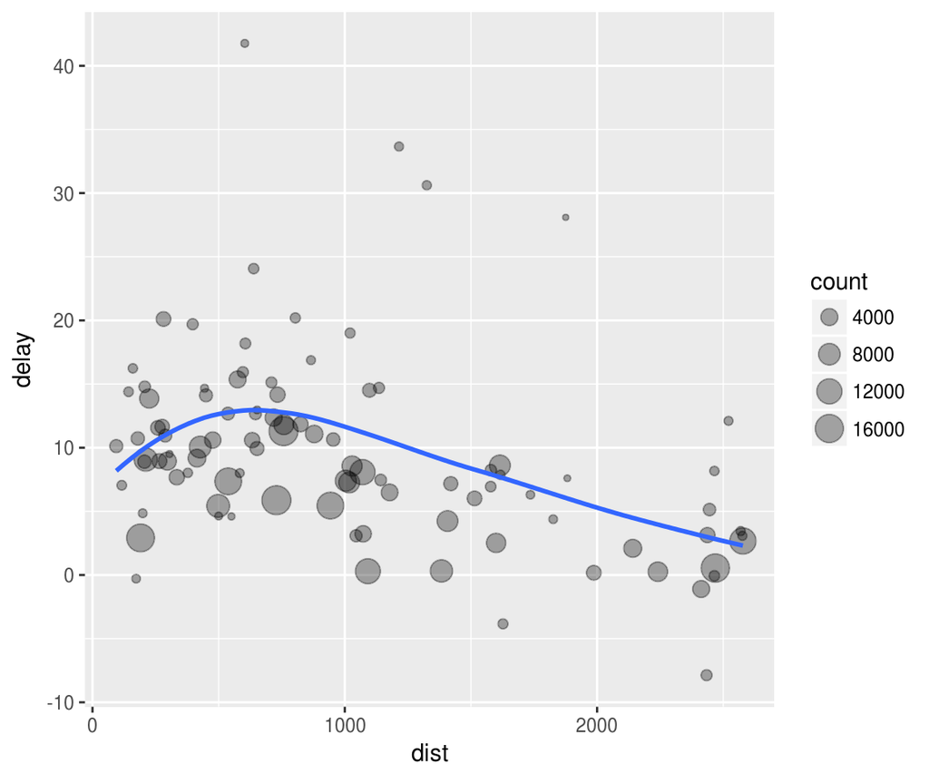

```r
delay <- filter(delay, count > 20, dest != "HNL")

# It looks like delays increase with distance up to ~750 miles
# and then decrease. Maybe as flights get longer there's more
# ability to make up delays in the air?
ggplot(data = delay, mapping = aes(x = dist, y = delay)) +
  geom_point(aes(size = count), alpha = 1/3) +
  geom_smooth(se = FALSE)
```

There are three steps to prepare this data:

1. Group flights by destination.
2. Summarise to compute distance, average delay, and number of flights.
3. Filter to remove noisy points and Honolulu airport, which is almost twice as far away as the next closest airport.

This code is a little frustrating to write because we have to give each intermediate data frame a name, even though we don’t care about it. Naming things is hard, so this slows down our analysis.

There’s another way to tackle the same problem with the pipe, `%>%`:

```r
delays <- flights %>%
  group_by(dest) %>%
  summarise(
    count = n(),
    dist = mean(distance, na.rm = TRUE),
    delay = mean(arr_delay, na.rm = TRUE)
  ) %>%
  filter(count > 20, dest != "HNL")
```

This focuses on the transformations, not what’s being transformed, which makes the code easier to read. You can read it as a series of imperative statements: group, then summarise, then filter. As suggested by this reading, a good way to pronounce `%>%` when reading code is “then”.

Behind the scenes, `x %>% f(y)` turns into `f(x, y)`, and `x %>% f(y) %>% g(z)` turns into `g(f(x, y), z)` and so on. You can use the pipe to rewrite multiple operations in a way that you can read left-to-right, top-to-bottom. We’ll use piping frequently from now on because it considerably improves the readability of code, and we’ll come back to it in more detail in [pipes].

Working with the pipe is one of the key criteria for belonging to the tidyverse. The only exception is ggplot2: it was written before the pipe was discovered. Unfortunately, the next iteration of ggplot2, ggvis, which does use the pipe, isn’t quite ready for prime time yet.

### Missing values

You may have wondered about the `na.rm` argument we used above. What happens if we don’t set it?

```r
flights %>%
  group_by(year, month, day) %>%
  summarise(mean = mean(dep_delay))
```

```
## Source: local data frame [365 x 4]
## Groups: year, month [?]
##
##     year month   day  mean
##    <int> <int> <int> <dbl>
## 1   2013     1     1    NA
## 2   2013     1     2    NA
## 3   2013     1     3    NA
## 4   2013     1     4    NA
## 5   2013     1     5    NA
## 6   2013     1     6    NA
## 7   2013     1     7    NA
## 8   2013     1     8    NA
## 9   2013     1     9    NA
## 10  2013     1    10    NA
## # ... with 355 more rows
```

We get a lot of missing values! That’s because aggregation functions obey the usual rule of missing values: if there’s any missing value in the input, the output will be a missing value. Fortunately, all aggregation functions have an `na.rm` argument which removes the missing values prior to computation:

```r
flights %>%
  group_by(year, month, day) %>%
  summarise(mean = mean(dep_delay, na.rm = TRUE))
```

```
## Source: local data frame [365 x 4]
## Groups: year, month [?]
##
##     year month   day      mean
##    <int> <int> <int>     <dbl>
## 1   2013     1     1 11.548926
## 2   2013     1     2 13.858824
## 3   2013     1     3 10.987832
## 4   2013     1     4  8.951595
## 5   2013     1     5  5.732218
## 6   2013     1     6  7.148014
## 7   2013     1     7  5.417204
## 8   2013     1     8  2.553073
## 9   2013     1     9  2.276477
## 10  2013     1    10  2.844995
## # ... with 355 more rows
```

In this case, where missing values represent cancelled flights, we could also tackle the problem by first removing the cancelled flights. We’ll save this dataset so we can reuse in the next few examples.

```r
not_cancelled <- flights %>%
  filter(!is.na(dep_delay), !is.na(arr_delay))

not_cancelled %>%
  group_by(year, month, day) %>%
  summarise(mean = mean(dep_delay))
```

```
## Source: local data frame [365 x 4]
## Groups: year, month [?]
##
##     year month   day      mean
##    <int> <int> <int>     <dbl>
## 1   2013     1     1 11.435620
## 2   2013     1     2 13.677802
## 3   2013     1     3 10.907778
## 4   2013     1     4  8.965859
## 5   2013     1     5  5.732218
## 6   2013     1     6  7.145959
## 7   2013     1     7  5.417204
## 8   2013     1     8  2.558296
## 9   2013     1     9  2.301232
## 10  2013     1    10  2.844995
## # ... with 355 more rows
```

### Counts

Whenever you do any aggregation, it’s always a good idea to include either a count (`n()`), or a count of non-missing values (`sum(!is.na(x))`). That way you can check that you’re not drawing conclusions based on very small amounts of data. For example, let’s look at the planes (identified by their tail number) that have the highest average delays:

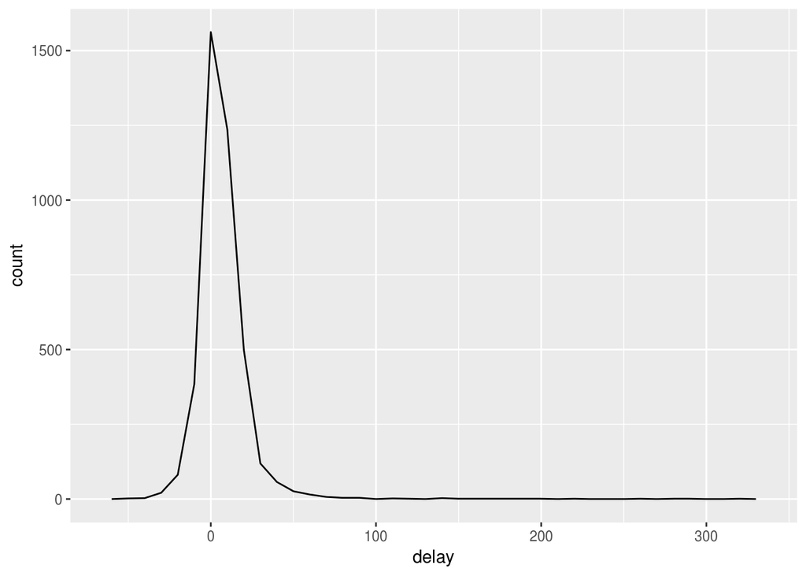

```r
delays <- not_cancelled %>%
  group_by(tailnum) %>%
  summarise(
    delay = mean(arr_delay)
  )

ggplot(data = delays, mapping = aes(x = delay)) +
  geom_freqpoly(binwidth = 10)
```

We see, there are some planes that have an *average* delay of 5 hours (300 minutes)!

The story is actually a little more nuanced. We can get more insight if we draw a scatterplot of number of flights vs. average delay:

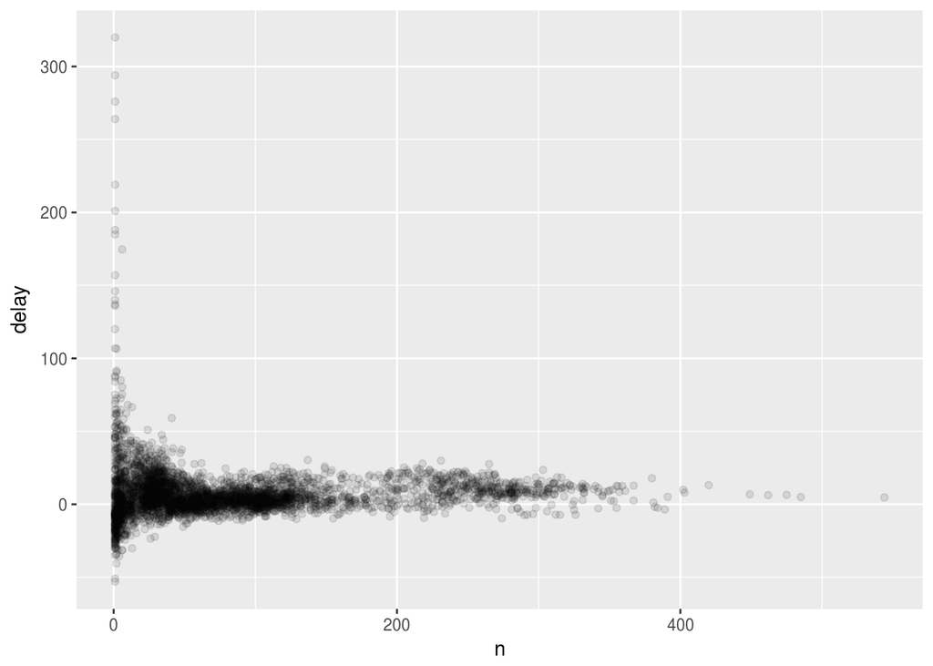

```r
delays <- not_cancelled %>%
  group_by(tailnum) %>%
  summarise(
    delay = mean(arr_delay, na.rm = TRUE),
    n = n()
  )

ggplot(data = delays, mapping = aes(x = n, y = delay)) +
  geom_point(alpha = 1/10)
```

Not surprisingly, there is much greater variation in the average delay when there are few flights. The shape of this plot is very characteristic: whenever you plot a mean (or other summary) vs. group size, you’ll see that the variation decreases as the sample size increases.

When looking at this sort of plot, it’s often useful to filter out the groups with the smallest numbers of observations, so you can see more of the pattern and less of the extreme variation in the smallest groups. This is what the following code does, as well as showing you a handy pattern for integrating ggplot2 into dplyr flows. It’s a bit painful that you have to switch from `%>%` to `+`, but once you get the hang of it, it’s quite convenient.

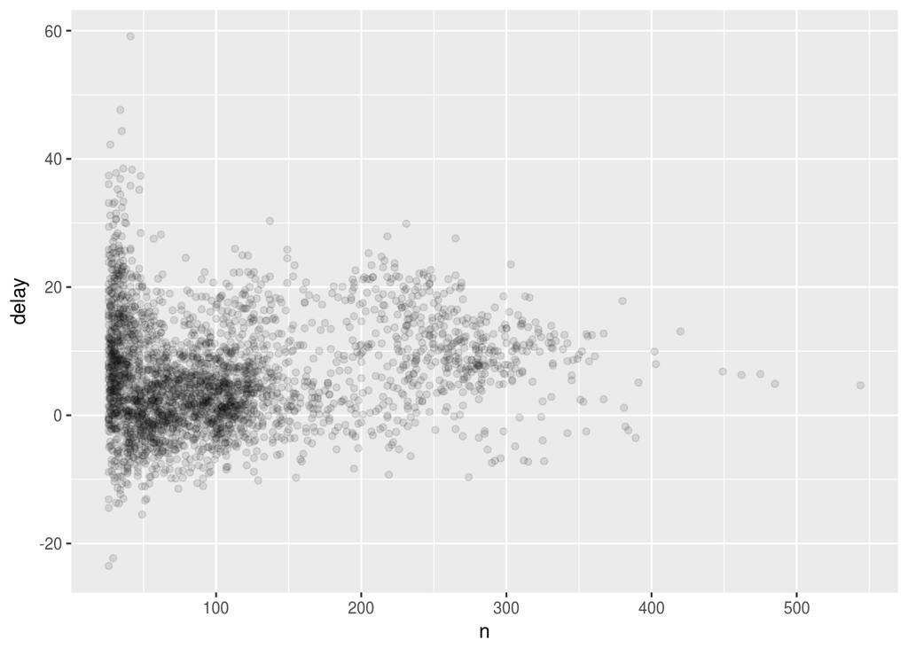

```r
delays %>%
  filter(n > 25) %>%
  ggplot(mapping = aes(x = n, y = delay)) +
    geom_point(alpha = 1/10)
```

RStudio tip: a useful keyboard shortcut is Cmd/Ctrl + Shift + P. This resends the previously sent chunk from the editor to the console. This is very convenient when you’re (e.g.) exploring the value of `n` in the example above. You send the whole block once with Cmd/Ctrl + Enter, then you modify the value of `n` and press Cmd/Ctrl + Shift + P to resend the complete block.

There’s another common variation of this type of pattern. Let’s look at how the average performance of batters in baseball is related to the number of times they’re at bat. Here we will use data from the **Lahman** package to compute the batting average (number of hits / number of attempts) of every major league baseball player.

When I plot the skill of the batter (measured by the batting average, `ba`) against the number of opportunities to hit the ball (measured by at bat, `ab`), you see two patterns:

1. As above, the variation in our aggregate decreases as we get more data points.
2. There’s a positive correlation between skill (`ba`) and opportunities to hit the ball (`ab`). This is because teams control who gets to play, and obviously they’ll pick their best players.

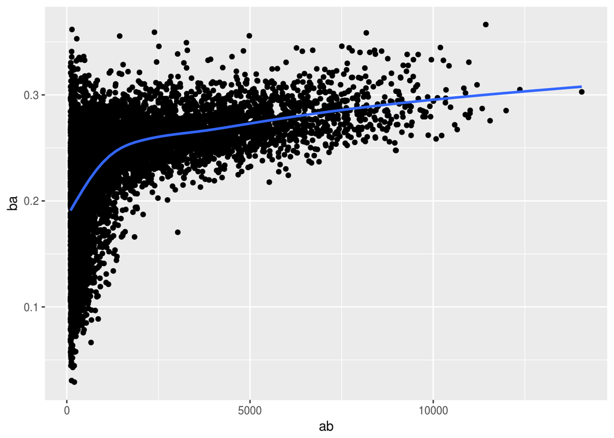

```r
# Convert to a tibble so it prints nicely
library(Lahman)

batting <- as_tibble(Lahman::Batting)
batters <- batting %>%
  group_by(playerID) %>%
  summarise(
    ba = sum(H, na.rm = TRUE) / sum(AB, na.rm = TRUE),
    ab = sum(AB, na.rm = TRUE)
  )

batters %>%
  filter(ab > 100) %>%
  ggplot(mapping = aes(x = ab, y = ba)) +
    geom_point() +
    geom_smooth(se = FALSE)
```

This also has important implications for ranking. If you naively sort on `desc(ba)`, the people with the best batting averages are clearly lucky, not skilled:

```r
batters %>%
  arrange(desc(ba))
```

```
## # A tibble: 18,659 × 3
##     playerID    ba    ab
##        <chr> <dbl> <int>
## 1  abramge01     1     1
## 2  banisje01     1     1
## 3  bartocl01     1     1
## 4   bassdo01     1     1
## 5  birasst01     1     2
## 6  bruneju01     1     1
## 7  burnscb01     1     1
## 8  cammaer01     1     1
## 9   campsh01     1     1
## 10 crockcl01     1     1
## # ... with 18,649 more rows
```

You can find a good explanation of this problem at http://varianceexplained.org/r/empirical_bayes_baseball/ and http://www.evanmiller.org/how-not-to-sort-by-average-rating.html.

### Useful summary functions

Just using means, counts, and sum can get you a long way, but R provides many other useful summary functions:

- Measures of location: we’ve used `mean(x)`, but `median(x)` is also useful. The mean is the sum divided by the length; the median is a value where 50% of `x` is above it, and 50% is below it.

  It’s sometimes useful to combine aggregation with logical subsetting. We haven’t talked about this sort of subsetting yet, but you’ll learn more about it in [subsetting].

  ```r
  not_cancelled %>%
    group_by(year, month, day) %>%
    summarise(
      avg_delay1 = mean(arr_delay),
      avg_delay2 = mean(arr_delay[arr_delay > 0]) # the average positive delay
    )
  ```

  ```
  ## Source: local data frame [365 x 5]
  ## Groups: year, month [?]
  ##
  ##     year month   day avg_delay1 avg_delay2
  ##    <int> <int> <int>      <dbl>      <dbl>
  ## 1   2013     1     1 12.6510229   32.48156
  ## 2   2013     1     2 12.6928879   32.02991
  ## 3   2013     1     3  5.7333333   27.66087
  ## 4   2013     1     4 -1.9328194   28.30976
  ## 5   2013     1     5 -1.5258020   22.55882
  ## 6   2013     1     6  4.2364294   24.37270
  ## 7   2013     1     7 -4.9473118   27.76132
  ## 8   2013     1     8 -3.2275785   20.78909
  ## 9   2013     1     9 -0.2642777   25.63415
  ## 10  2013     1    10 -5.8988159   27.34545
  ## # ... with 355 more rows
  ```

- Measures of spread: `sd(x)`, `IQR(x)`, `mad(x)`. The mean squared deviation, or standard deviation or sd for short, is the standard measure of spread. The interquartile range `IQR()` and median absolute deviation `mad(x)` are robust equivalents that may be more useful if you have outliers.

  ```r
  # Why is distance to some destinations more variable than to others?
  not_cancelled %>%
    group_by(dest) %>%
    summarise(distance_sd = sd(distance)) %>%
    arrange(desc(distance_sd))
  ```

  ```
  ## # A tibble: 104 × 2
  ##     dest distance_sd
  ##    <chr>       <dbl>
  ## 1    EGE   10.542765
  ## 2    SAN   10.350094
  ## 3    SFO   10.216017
  ## 4    HNL   10.004197
  ## 5    SEA    9.977993
  ## 6    LAS    9.907786
  ## 7    PDX    9.873299
  ## 8    PHX    9.862546
  ## 9    LAX    9.657195
  ## 10   IND    9.458066
  ## # ... with 94 more rows
  ```

- Measures of rank: `min(x)`, `quantile(x, 0.25)`, `max(x)`. Quantiles are a generalisation of the median. For example, `quantile(x, 0.25)` will find a value of `x` that is greater than 25% of the values, and less than the remaining 75%.

  ```r
  # When do the first and last flights leave each day?
  not_cancelled %>%
    group_by(year, month, day) %>%
    summarise(
      first = min(dep_time),
      last = max(dep_time)
    )
  ```

  ```
  ## Source: local data frame [365 x 5]
  ## Groups: year, month [?]
  ##
  ##     year month   day first  last
  ##    <int> <int> <int> <int> <int>
  ## 1   2013     1     1   517  2356
  ## 2   2013     1     2    42  2354
  ## 3   2013     1     3    32  2349
  ## 4   2013     1     4    25  2358
  ## 5   2013     1     5    14  2357
  ## 6   2013     1     6    16  2355
  ## 7   2013     1     7    49  2359
  ## 8   2013     1     8   454  2351
  ## 9   2013     1     9     2  2252
  ## 10  2013     1    10     3  2320
  ## # ... with 355 more rows
  ```

- Measures of position: `first(x)`, `nth(x, 2)`, `last(x)`. These work similarly to `x[1]`, `x[2]`, and `x[length(x)]` but let you set a default value if that position does not exist (i.e. you’re trying to get the 3rd element from a group that only has two elements). For example, we can find the first and last departure for each day:

  ```r
  not_cancelled %>%
    group_by(year, month, day) %>%
    summarise(
      first_dep = first(dep_time),
      last_dep = last(dep_time)
    )
  ```

  ```
  ## Source: local data frame [365 x 5]
  ## Groups: year, month [?]
  ##
  ##     year month   day first_dep last_dep
  ##    <int> <int> <int>     <int>    <int>
  ## 1   2013     1     1       517     2356
  ## 2   2013     1     2        42     2354
  ## 3   2013     1     3        32     2349
  ## 4   2013     1     4        25     2358
  ## 5   2013     1     5        14     2357
  ## 6   2013     1     6        16     2355
  ## 7   2013     1     7        49     2359
  ## 8   2013     1     8       454     2351
  ## 9   2013     1     9         2     2252
  ## 10  2013     1    10         3     2320
  ## # ... with 355 more rows
  ```

  These functions are complementary to filtering on ranks. Filtering gives you all variables, with each observation in a separate row:

  ```r
  not_cancelled %>%
    group_by(year, month, day) %>%
    mutate(r = min_rank(desc(dep_time))) %>%
    filter(r %in% range(r))
  ```

  ```
  ## Source: local data frame [770 x 20]
  ## Groups: year, month, day [365]
  ##
  ##     year month   day dep_time sched_dep_time dep_delay arr_time
  ##    <int> <int> <int>    <int>          <int>     <dbl>    <int>
  ## 1   2013     1     1      517            515         2      830
  ## 2   2013     1     1     2356           2359        -3      425
  ## 3   2013     1     2       42           2359        43      518
  ## 4   2013     1     2     2354           2359        -5      413
  ## 5   2013     1     3       32           2359        33      504
  ## 6   2013     1     3     2349           2359       -10      434
  ## 7   2013     1     4       25           2359        26      505
  ## 8   2013     1     4     2358           2359        -1      429
  ## 9   2013     1     4     2358           2359        -1      436
  ## 10  2013     1     5       14           2359        15      503
  ## # ... with 760 more rows, and 13 more variables: sched_arr_time <int>,
  ## #   arr_delay <dbl>, carrier <chr>, flight <int>, tailnum <chr>,
  ## #   origin <chr>, dest <chr>, air_time <dbl>, distance <dbl>, hour <dbl>,
  ## #   minute <dbl>, time_hour <dttm>, r <int>
  ```

- Counts: You’ve seen `n()`, which takes no arguments, and returns the size of the current group. To count the number of non-missing values, use `sum(!is.na(x))`. To count the number of distinct (unique) values, use `n_distinct(x)`.

  ```r
  # Which destinations have the most carriers?
  not_cancelled %>%
    group_by(dest) %>%
    summarise(carriers = n_distinct(carrier)) %>%
    arrange(desc(carriers))
  ```

  ```
  ## # A tibble: 104 × 2
  ##     dest carriers
  ##    <chr>    <int>
  ## 1    ATL        7
  ## 2    BOS        7
  ## 3    CLT        7
  ## 4    ORD        7
  ## 5    TPA        7
  ## 6    AUS        6
  ## 7    DCA        6
  ## 8    DTW        6
  ## 9    IAD        6
  ## 10   MSP        6
  ## # ... with 94 more rows
  ```

  Counts are so useful that dplyr provides a simple helper if all you want is a count:

  ```r
  not_cancelled %>%
    count(dest)
  ```

  ```
  ## # A tibble: 104 × 2
  ##     dest     n
  ##    <chr> <int>
  ## 1    ABQ   254
  ## 2    ACK   264
  ## 3    ALB   418
  ## 4    ANC     8
  ## 5    ATL 16837
  ## 6    AUS  2411
  ## 7    AVL   261
  ## 8    BDL   412
  ## 9    BGR   358
  ## 10   BHM   269
  ## # ... with 94 more rows
  ```

  You can optionally provide a weight variable. For example, you could use this to “count” (sum) the total number of miles a plane flew:

  ```r
  not_cancelled %>%
    count(tailnum, wt = distance)
  ```

  ```
  ## # A tibble: 4,037 × 2
  ##    tailnum      n
  ##      <chr>  <dbl>
  ## 1   D942DN   3418
  ## 2   N0EGMQ 239143
  ## 3   N10156 109664
  ## 4   N102UW  25722
  ## 5   N103US  24619
  ## 6   N104UW  24616
  ## 7   N10575 139903
  ## 8   N105UW  23618
  ## 9   N107US  21677
  ## 10  N108UW  32070
  ## # ... with 4,027 more rows
  ```

- Counts and proportions of logical values: `sum(x > 10)`, `mean(y == 0)`. When used with numeric functions, `TRUE` is converted to 1 and `FALSE` to 0. This makes `sum()` and `mean()` very useful: `sum(x)` gives the number of `TRUE`s in `x`, and `mean(x)` gives the proportion.

  ```r
  # How many flights left before 5am? (these usually indicate delayed
  # flights from the previous day)
  not_cancelled %>%
    group_by(year, month, day) %>%
    summarise(n_early = sum(dep_time < 500))
  ```

  ```
  ## Source: local data frame [365 x 4]
  ## Groups: year, month [?]
  ##
  ##     year month   day n_early
  ##    <int> <int> <int>   <int>
  ## 1   2013     1     1       0
  ## 2   2013     1     2       3
  ## 3   2013     1     3       4
  ## 4   2013     1     4       3
  ## 5   2013     1     5       3
  ## 6   2013     1     6       2
  ## 7   2013     1     7       2
  ## 8   2013     1     8       1
  ## 9   2013     1     9       3
  ## 10  2013     1    10       3
  ## # ... with 355 more rows
  ```

  ```r
  # What proportion of flights are delayed by more than an hour?
  not_cancelled %>%
    group_by(year, month, day) %>%
    summarise(hour_perc = mean(arr_delay > 60))
  ```

  ```
  ## Source: local data frame [365 x 4]
  ## Groups: year, month [?]
  ##
  ##     year month   day  hour_perc
  ##    <int> <int> <int>      <dbl>
  ## 1   2013     1     1 0.07220217
  ## 2   2013     1     2 0.08512931
  ## 3   2013     1     3 0.05666667
  ## 4   2013     1     4 0.03964758
  ## 5   2013     1     5 0.03486750
  ## 6   2013     1     6 0.04704463
  ## 7   2013     1     7 0.03333333
  ## 8   2013     1     8 0.02130045
  ## 9   2013     1     9 0.02015677
  ## 10  2013     1    10 0.01829925
  ## # ... with 355 more rows
  ```

### Grouping by multiple variables

When you group by multiple variables, each summary peels off one level of the grouping. That makes it easy to progressively roll up a dataset:

```r
daily <- group_by(flights, year, month, day)
(per_day   <- summarise(daily, flights = n()))
```

```
## Source: local data frame [365 x 4]
## Groups: year, month [?]
##
##     year month   day flights
##    <int> <int> <int>   <int>
## 1   2013     1     1     842
## 2   2013     1     2     943
## 3   2013     1     3     914
## 4   2013     1     4     915
## 5   2013     1     5     720
## 6   2013     1     6     832
## 7   2013     1     7     933
## 8   2013     1     8     899
## 9   2013     1     9     902
## 10  2013     1    10     932
## # ... with 355 more rows
```

```r
(per_month <- summarise(per_day, flights = sum(flights)))
```

```
## Source: local data frame [12 x 3]
## Groups: year [?]
##
##     year month flights
##    <int> <int>   <int>
## 1   2013     1   27004
## 2   2013     2   24951
## 3   2013     3   28834
## 4   2013     4   28330
## 5   2013     5   28796
## 6   2013     6   28243
## 7   2013     7   29425
## 8   2013     8   29327
## 9   2013     9   27574
## 10  2013    10   28889
## 11  2013    11   27268
## 12  2013    12   28135
```

```r
(per_year  <- summarise(per_month, flights = sum(flights)))
```

```
## # A tibble: 1 × 2
##    year flights
##   <int>   <int>
## 1  2013  336776
```

Be careful when progressively rolling up summaries: it’s OK for sums and counts, but you need to think about weighting means and variances, and it’s not possible to do it exactly for rank-based statistics like the median. In other words, the sum of groupwise sums is the overall sum, but the median of groupwise medians is not the overall median.

### Ungrouping

If you need to remove grouping, and return to operations on ungrouped data, use `ungroup()`.

```r
daily %>%
  ungroup() %>%             # no longer grouped by date
  summarise(flights = n())  # all flights
```

```
## # A tibble: 1 × 1
##   flights
##     <int>
## 1  336776
```

### Exercises

1. Brainstorm at least 5 different ways to assess the typical delay characteristics of a group of flights. Consider the following scenarios:
   - A flight is 15 minutes early 50% of the time, and 15 minutes late 50% of the time.
   - A flight is always 10 minutes late.
   - A flight is 30 minutes early 50% of the time, and 30 minutes late 50% of the time.
   - 99% of the time a flight is on time. 1% of the time it’s 2 hours late.

   Which is more important: arrival delay or departure delay?
2. Come up with another approach that will give you the same output as `not_cancelled %>% count(dest)` and `not_cancelled %>% count(tailnum, wt = distance)` (without using `count()`).
3. Our definition of cancelled flights (`is.na(dep_delay) | is.na(arr_delay)` ) is slightly suboptimal. Why? Which is the most important column?
4. Look at the number of cancelled flights per day. Is there a pattern? Is the proportion of cancelled flights related to the average delay?
5. Which carrier has the worst delays? Challenge: can you disentangle the effects of bad airports vs. bad carriers? Why/why not? (Hint: think about `flights %>% group_by(carrier, dest) %>% summarise(n())`)
6. For each plane, count the number of flights before the first delay of greater than 1 hour.
7. What does the `sort` argument to `count()` do. When might you use it?

## Grouped mutates (and filters)

Grouping is most useful in conjunction with `summarise()`, but you can also do convenient operations with `mutate()` and `filter()`:

```r
flights_sml <- select(flights,
  year:day,
  ends_with("delay"),
  distance,
  air_time
)
mutate(flights_sml,
  gain = arr_delay - dep_delay,
  speed = distance / air_time * 60
)
```

```
## # A tibble: 336,776 × 9
##     year month   day dep_delay arr_delay distance air_time  gain    speed
##    <int> <int> <int>     <dbl>     <dbl>    <dbl>    <dbl> <dbl>    <dbl>
## 1   2013     1     1         2        11     1400      227     9 370.0441
## 2   2013     1     1         4        20     1416      227    16 374.2731
## 3   2013     1     1         2        33     1089      160    31 408.3750
## 4   2013     1     1        -1       -18     1576      183   -17 516.7213
## 5   2013     1     1        -6       -25      762      116   -19 394.1379
## 6   2013     1     1        -4        12      719      150    16 287.6000
## 7   2013     1     1        -5        19     1065      158    24 404.4304
## 8   2013     1     1        -3       -14      229       53   -11 259.2453
## 9   2013     1     1        -3        -8      944      140    -5 404.5714
## 10  2013     1     1        -2         8      733      138    10 318.6957
## # ... with 336,766 more rows
```

- Find all groups bigger than a threshold:

  ```r
  popular_dests <- flights %>%
    group_by(dest) %>%
    filter(n() > 365)
  popular_dests
  ```

  ```
  ## Source: local data frame [332,577 x 19]
  ## Groups: dest [77]
  ##
  ##     year month   day dep_time sched_dep_time dep_delay arr_time
  ##    <int> <int> <int>    <int>          <int>     <dbl>    <int>
  ## 1   2013     1     1      517            515         2      830
  ## 2   2013     1     1      533            529         4      850
  ## 3   2013     1     1      542            540         2      923
  ## 4   2013     1     1      544            545        -1     1004
  ## 5   2013     1     1      554            600        -6      812
  ## 6   2013     1     1      554            558        -4      740
  ## 7   2013     1     1      555            600        -5      913
  ## 8   2013     1     1      557            600        -3      709
  ## 9   2013     1     1      557            600        -3      838
  ## 10  2013     1     1      558            600        -2      753
  ## # ... with 332,567 more rows, and 12 more variables: sched_arr_time <int>,
  ## #   arr_delay <dbl>, carrier <chr>, flight <int>, tailnum <chr>,
  ## #   origin <chr>, dest <chr>, air_time <dbl>, distance <dbl>, hour <dbl>,
  ## #   minute <dbl>, time_hour <dttm>
  ```

- Standardise to compute per group metrics:

  ```r
  popular_dests %>%
    filter(arr_delay > 0) %>%
    mutate(prop_delay = arr_delay / sum(arr_delay)) %>%
    select(year:day, dest, arr_delay, prop_delay)
  ```

  ```
  ## Source: local data frame [131,106 x 6]
  ## Groups: dest [77]
  ##
  ##     year month   day  dest arr_delay   prop_delay
  ##    <int> <int> <int> <chr>     <dbl>        <dbl>
  ## 1   2013     1     1   IAH        11 1.106740e-04
  ## 2   2013     1     1   IAH        20 2.012255e-04
  ## 3   2013     1     1   MIA        33 2.350026e-04
  ## 4   2013     1     1   ORD        12 4.239594e-05
  ## 5   2013     1     1   FLL        19 9.377853e-05
  ## 6   2013     1     1   ORD         8 2.826396e-05
  ## 7   2013     1     1   LAX         7 3.444441e-05
  ## 8   2013     1     1   DFW        31 2.817951e-04
  ## 9   2013     1     1   ATL        12 3.996017e-05
  ## 10  2013     1     1   DTW        16 1.157257e-04
  ## # ... with 131,096 more rows
  ```

A grouped filter is a grouped mutate followed by an ungrouped filter. I generally avoid them except for quick and dirty manipulations: otherwise it’s hard to check that you’ve done the manipulation correctly.

Functions that work most naturally in grouped mutates and filters are known as window functions (vs. the summary functions used for summaries). You can learn more about useful window functions in the corresponding vignette: `vignette("window-functions")`.

### Exercises

1. Refer back to the table of useful mutate and filtering functions. Describe how each operation changes when you combine it with grouping.
2. Which plane (`tailnum`) has the worst on-time record?
3. What time of day should you fly if you want to avoid delays as much as possible?
4. For each destination, compute the total minutes of delay. For each, flight, compute the proportion of the total delay for its destination.
5. Delays are typically temporally correlated: even once the problem that caused the initial delay has been resolved, later flights are delayed to allow earlier flights to leave. Using `lag()` explore how the delay of a flight is related to the delay of the immediately preceding flight.
6. Look at each destination. Can you find flights that are suspiciously fast? (i.e. flights that represent a potential data entry error). Compute the air time a flight relative to the shortest flight to that destination. Which flights were most delayed in the air?
7. Find all destinations that are flown by at least two carriers. Use that information to rank the carriers.